# Supervised Machine Learning on Secondary School Performance

### STAT 527 - Jingbo Liu - Fall 2021

### Author: Gabe Taylor

### Agenda

# Data Description

[figure not shown]

|  | school | sex | age | address | famsize | Pstatus | Medu | Fedu | Mjob | Fjob | ... | famrel | freetime | goout | Dalc | Walc | health | absences | G1 | G2 | G3 |
| --- | --- | --- | --- | --- | --- | --- | --- | --- | --- | --- | --- | --- | --- | --- | --- | --- | --- | --- | --- | --- | --- |
| 0 | GP | F | 18 | U | GT3 | A | 4 | 4 | at_home | teacher | ... | 4 | 3 | 4 | 1 | 1 | 3 | 6 | 5 | 6 | 6 |
| 1 | GP | F | 17 | U | GT3 | T | 1 | 1 | at_home | other | ... | 5 | 3 | 3 | 1 | 1 | 3 | 4 | 5 | 5 | 6 |
| 2 | GP | F | 15 | U | LE3 | T | 1 | 1 | at_home | other | ... | 4 | 3 | 2 | 2 | 3 | 3 | 10 | 7 | 8 | 10 |
| 3 | GP | F | 15 | U | GT3 | T | 4 | 2 | health | services | ... | 3 | 2 | 2 | 1 | 1 | 5 | 2 | 15 | 14 | 15 |
| 4 | GP | F | 16 | U | GT3 | T | 3 | 3 | other | other | ... | 4 | 3 | 2 | 1 | 2 | 5 | 4 | 6 | 10 | 10 |
| ... | ... | ... | ... | ... | ... | ... | ... | ... | ... | ... | ... | ... | ... | ... | ... | ... | ... | ... | ... | ... | ... |
| 390 | MS | M | 20 | U | LE3 | A | 2 | 2 | services | services | ... | 5 | 5 | 4 | 4 | 5 | 4 | 11 | 9 | 9 | 9 |
| 391 | MS | M | 17 | U | LE3 | T | 3 | 1 | services | services | ... | 2 | 4 | 5 | 3 | 4 | 2 | 3 | 14 | 16 | 16 |
| 392 | MS | M | 21 | R | GT3 | T | 1 | 1 | other | other | ... | 5 | 5 | 3 | 3 | 3 | 3 | 3 | 10 | 8 | 7 |
| 393 | MS | M | 18 | R | LE3 | T | 3 | 2 | services | other | ... | 4 | 4 | 1 | 3 | 4 | 5 | 0 | 11 | 12 | 10 |
| 394 | MS | M | 19 | U | LE3 | T | 1 | 1 | other | at_home | ... | 3 | 2 | 3 | 3 | 3 | 5 | 5 | 8 | 9 | 9 |

395 rows × 33 columns

# EDA

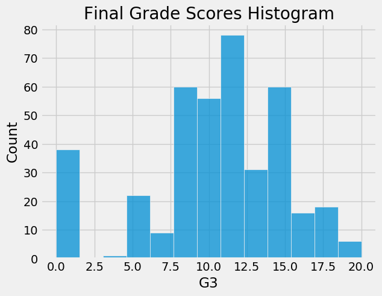

## Box-plots of Final Grade by Feature

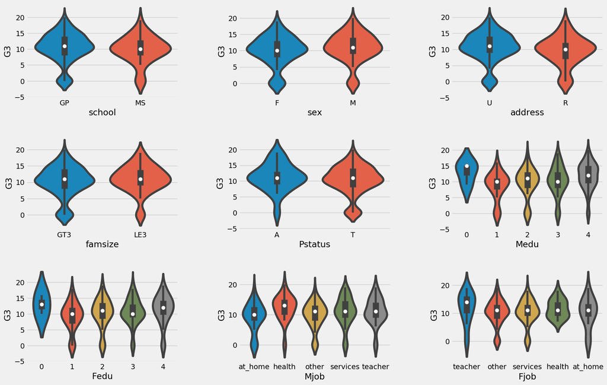

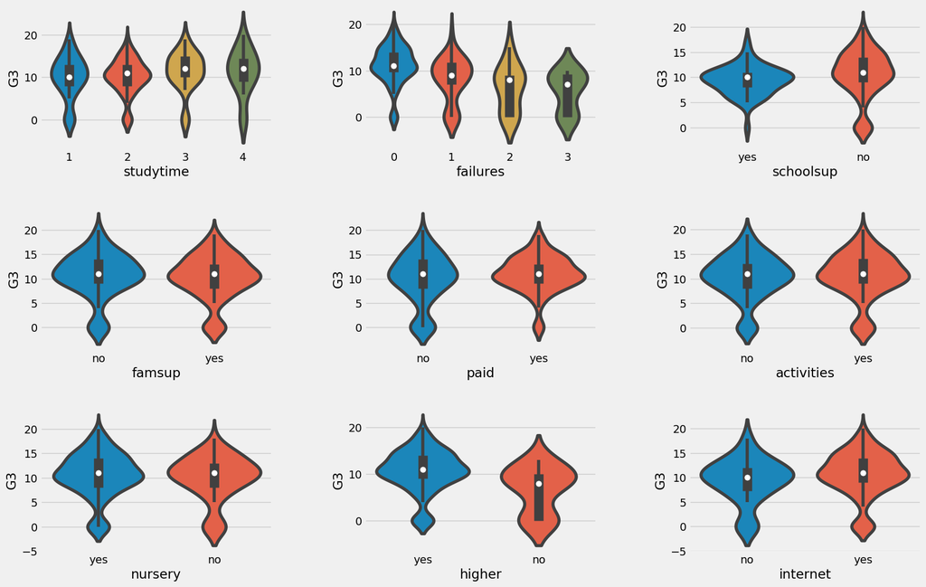

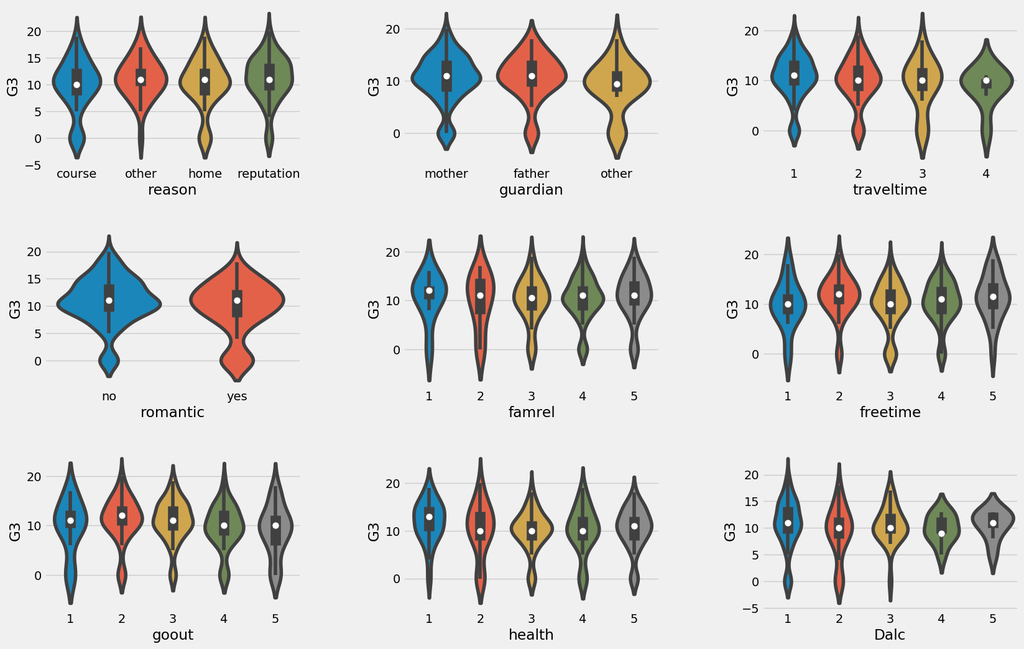

# Data PreProcessing

## One-Hot Encoding

Dropped reference level in order to avoid dummy-variable trap

|  | school_MS | sex_M | address_U | famsize_LE3 | Pstatus_T | Medu_1 | Medu_2 | Medu_3 | Medu_4 | Fedu_1 | ... | Dalc_4 | Dalc_5 | Walc_2 | Walc_3 | Walc_4 | Walc_5 | health_2 | health_3 | health_4 | health_5 |
| --- | --- | --- | --- | --- | --- | --- | --- | --- | --- | --- | --- | --- | --- | --- | --- | --- | --- | --- | --- | --- | --- |
| 0 | 0 | 0 | 1 | 0 | 0 | 0 | 0 | 0 | 1 | 0 | ... | 0 | 0 | 0 | 0 | 0 | 0 | 0 | 1 | 0 | 0 |
| 1 | 0 | 0 | 1 | 0 | 1 | 1 | 0 | 0 | 0 | 1 | ... | 0 | 0 | 0 | 0 | 0 | 0 | 0 | 1 | 0 | 0 |
| 2 | 0 | 0 | 1 | 1 | 1 | 1 | 0 | 0 | 0 | 1 | ... | 0 | 0 | 0 | 1 | 0 | 0 | 0 | 1 | 0 | 0 |
| 3 | 0 | 0 | 1 | 0 | 1 | 0 | 0 | 0 | 1 | 0 | ... | 0 | 0 | 0 | 0 | 0 | 0 | 0 | 0 | 0 | 1 |
| 4 | 0 | 0 | 1 | 0 | 1 | 0 | 0 | 1 | 0 | 0 | ... | 0 | 0 | 1 | 0 | 0 | 0 | 0 | 0 | 0 | 1 |
| ... | ... | ... | ... | ... | ... | ... | ... | ... | ... | ... | ... | ... | ... | ... | ... | ... | ... | ... | ... | ... | ... |
| 390 | 1 | 1 | 1 | 1 | 0 | 0 | 1 | 0 | 0 | 0 | ... | 1 | 0 | 0 | 0 | 0 | 1 | 0 | 0 | 1 | 0 |
| 391 | 1 | 1 | 1 | 1 | 1 | 0 | 0 | 1 | 0 | 1 | ... | 0 | 0 | 0 | 0 | 1 | 0 | 1 | 0 | 0 | 0 |
| 392 | 1 | 1 | 0 | 0 | 1 | 1 | 0 | 0 | 0 | 1 | ... | 0 | 0 | 0 | 1 | 0 | 0 | 0 | 1 | 0 | 0 |
| 393 | 1 | 1 | 0 | 1 | 1 | 0 | 0 | 1 | 0 | 0 | ... | 0 | 0 | 0 | 0 | 1 | 0 | 0 | 0 | 0 | 1 |
| 394 | 1 | 1 | 1 | 1 | 1 | 1 | 0 | 0 | 0 | 1 | ... | 0 | 0 | 0 | 1 | 0 | 0 | 0 | 0 | 0 | 1 |

395 rows × 67 columns

### Final DataFrame

|  | school_MS | sex_M | address_U | famsize_LE3 | Pstatus_T | Medu_1 | Medu_2 | Medu_3 | Medu_4 | Fedu_1 | ... | Walc_3 | Walc_4 | Walc_5 | health_2 | health_3 | health_4 | health_5 | age | absences | G3 |
| --- | --- | --- | --- | --- | --- | --- | --- | --- | --- | --- | --- | --- | --- | --- | --- | --- | --- | --- | --- | --- | --- |
| 0 | 0 | 0 | 1 | 0 | 0 | 0 | 0 | 0 | 1 | 0 | ... | 0 | 0 | 0 | 0 | 1 | 0 | 0 | 18 | 6 | 6 |
| 1 | 0 | 0 | 1 | 0 | 1 | 1 | 0 | 0 | 0 | 1 | ... | 0 | 0 | 0 | 0 | 1 | 0 | 0 | 17 | 4 | 6 |
| 2 | 0 | 0 | 1 | 1 | 1 | 1 | 0 | 0 | 0 | 1 | ... | 1 | 0 | 0 | 0 | 1 | 0 | 0 | 15 | 10 | 10 |
| 3 | 0 | 0 | 1 | 0 | 1 | 0 | 0 | 0 | 1 | 0 | ... | 0 | 0 | 0 | 0 | 0 | 0 | 1 | 15 | 2 | 15 |
| 4 | 0 | 0 | 1 | 0 | 1 | 0 | 0 | 1 | 0 | 0 | ... | 0 | 0 | 0 | 0 | 0 | 0 | 1 | 16 | 4 | 10 |
| ... | ... | ... | ... | ... | ... | ... | ... | ... | ... | ... | ... | ... | ... | ... | ... | ... | ... | ... | ... | ... | ... |
| 390 | 1 | 1 | 1 | 1 | 0 | 0 | 1 | 0 | 0 | 0 | ... | 0 | 0 | 1 | 0 | 0 | 1 | 0 | 20 | 11 | 9 |
| 391 | 1 | 1 | 1 | 1 | 1 | 0 | 0 | 1 | 0 | 1 | ... | 0 | 1 | 0 | 1 | 0 | 0 | 0 | 17 | 3 | 16 |
| 392 | 1 | 1 | 0 | 0 | 1 | 1 | 0 | 0 | 0 | 1 | ... | 1 | 0 | 0 | 0 | 1 | 0 | 0 | 21 | 3 | 7 |
| 393 | 1 | 1 | 0 | 1 | 1 | 0 | 0 | 1 | 0 | 0 | ... | 0 | 1 | 0 | 0 | 0 | 0 | 1 | 18 | 0 | 10 |
| 394 | 1 | 1 | 1 | 1 | 1 | 1 | 0 | 0 | 0 | 1 | ... | 1 | 0 | 0 | 0 | 0 | 0 | 1 | 19 | 5 | 9 |

395 rows × 70 columns

# Mean Model

$$RMSE = \sqrt{\frac{1}{n} \sum_{i = 1}^n (y_i - \hat y_i)^2}$$

```
Mean Model RMSE: 4.576
```

# Cross-Validation

### 10 Fold Cross Validation

1. Split data into 10 folds
2. Reserve 1 fold for validation (scoring)
3. Train model on remaining 9 folds

[figure not shown]

### How to evaluate performance

One could take the average error over all of the folds:

[figure not shown]

Alternatively, one could append the cross-validation predictions to the original training data, and score the predictions using the the full training observations

[figure not shown]

### What about the Test Data?

In practice, it is useful to score the final model on a holdout set in order to evaluate how well the the model will generalize to unseen data. In the project, due to the small training size, we will not reserve a portion of the data for a hold out, but instead, we will construct a 'test set' using the 10 folds as illustrated in the second method in previous slide.

- This is how the original paper scored their models
- This is how H2o obtains cross-validation metrics

# OLS Model

### Summary

```
Training RMSE: 3.672
Cross Validation RMSE: 4.544
```

|  | names | standardized_coefficients |
| --- | --- | --- |
| 0 | Intercept | 10.415190 |
| 1 | school_MS | 0.198070 |
| 2 | sex_M | 0.595258 |
| 3 | address_U | 0.177713 |
| 4 | famsize_LE3 | 0.443414 |
| ... | ... | ... |
| 65 | health_3 | -0.550275 |
| 66 | health_4 | -0.485483 |
| 67 | health_5 | -0.607102 |
| 68 | age | -0.424773 |
| 69 | absences | 0.530834 |

70 rows × 2 columns

# LASSO Model

### Summary

```
Training RMSE: 4.086
Cross Validation RMSE: 4.362
```

### Coefficients

|  | names | standardized_coefficients |
| --- | --- | --- |
| 0 | Intercept | 10.415190 |
| 1 | school_MS | 0.000000 |
| 2 | sex_M | 0.193052 |
| 3 | address_U | 0.034271 |
| 4 | famsize_LE3 | 0.072247 |
| ... | ... | ... |
| 65 | health_3 | 0.000000 |
| 66 | health_4 | 0.000000 |
| 67 | health_5 | 0.000000 |
| 68 | age | -0.064371 |
| 69 | absences | 0.007380 |

70 rows × 2 columns

|  | names | standardized_coefficients |
| --- | --- | --- |
| 0 | Intercept | 10.415190 |
| 1 | Medu_4 | 0.336882 |
| 2 | Mjob_services | 0.204124 |
| 3 | sex_M | 0.193052 |
| 4 | higher_yes | 0.168823 |
| 5 | studytime_3 | 0.118721 |
| 6 | goout_2 | 0.107856 |
| 7 | Mjob_health | 0.074712 |
| 8 | famsize_LE3 | 0.072247 |
| 9 | freetime_5 | 0.054082 |
| 10 | reason_reputation | 0.052682 |
| 11 | address_U | 0.034271 |
| 12 | freetime_2 | 0.030301 |
| 13 | absences | 0.007380 |
| 14 | internet_yes | 0.002141 |
| 15 | Medu_1 | -0.061367 |
| 16 | schoolsup_yes | -0.063288 |
| 17 | age | -0.064371 |
| 18 | goout_4 | -0.067517 |
| 19 | Dalc_2 | -0.077596 |
| 20 | goout_5 | -0.121048 |
| 21 | romantic_yes | -0.170427 |
| 22 | freetime_3 | -0.241182 |
| 23 | failures_3 | -0.604934 |
| 24 | failures_1 | -0.608071 |
| 25 | failures_2 | -0.621929 |

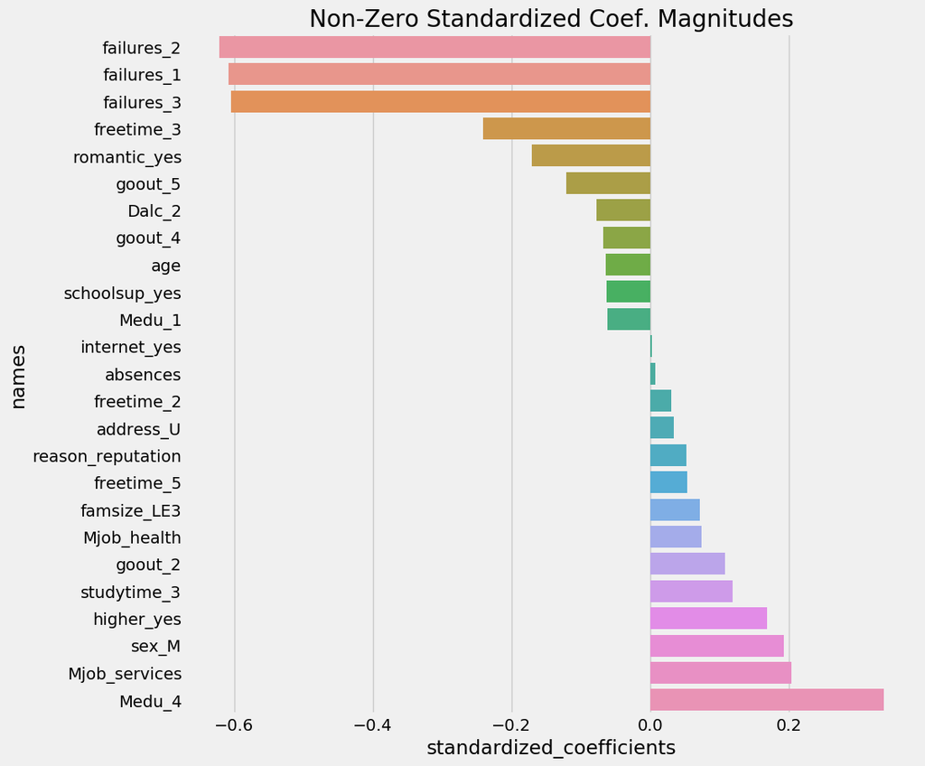

# Lambda Search

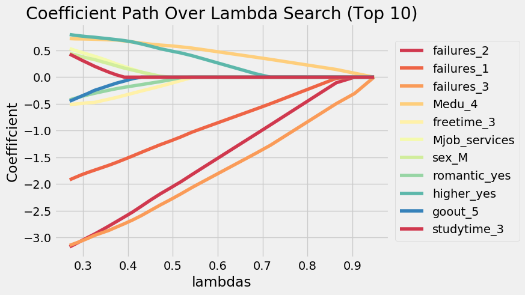

| Model | Train RMSE | Cross-Validated RMSE |
| --- | --- | --- |
| OLS | **3.672** | 4.544 |
| LASSO | 4.086 | **4.362** |

# Gradient Boosting Machines

# Decision Tree Primer

[figure not shown]

[source](https://bradleyboehmke.github.io/HOML/DT.html)

[figure not shown]

[source](https://bradleyboehmke.github.io/HOML/DT.html)

# How to fit Regression Tree?

$$f(x) = \sum_{m=1}^M c_m I(x \in r_m)$$

### Simple task if objective function is sum of squares

$$\hat c_m = \text{ave} (y_i | x_i \in R_m)$$

$$R_1(j, s) = {X|X_j \leq s} \quad \text{and} \quad R_2(j, s) = {X|X_j > s}$$

$$\min_{j, s} \left[ \min_{c_1} \sum_{x_i \in R_1(j, s)} (y_i - c_1)^2 + \min_{c_2} \sum_{x_i \in R_1(j, s)} (y_i - c_2)^2 \right]$$

$$\hat c_1 = \text{ave}(y_i |x_i \in R_1(j, s)) \quad \text{and} \quad \hat c_2 = \text{ave}(y_i |x_i \in R_2(j, s))$$

# Why Trees?

### Pros

- Highly interpretable
- Interactions for free
- Natural handling of categorical predictors
- No assumptions

### Cons

- Empirically demonstrated to overfit easily
- Greedy, stuck in local optima

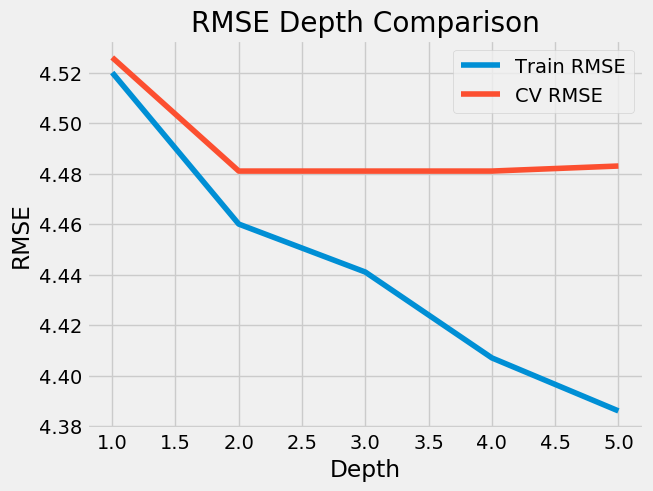

[figure not shown]

| Model | Train RMSE | Cross-Validated RMSE |
| --- | --- | --- |
| OLS | **3.672** | 4.544 |
| LASSO | 4.086 | **4.362** |
| Decision Tree | 4.460 | 4.481 |

# Boosting

### How to boost decision trees

Sequentially fitting additive decision trees to the residuals of the current model.

[figure not shown]

Take

$$L(x, y) = 0.5(x - y)^2$$$$\frac{d}{dy}L(x, y) = -(x - y)$$

Then

$$r_{im} = -\left[\frac{d L(y_i, f(x_i)}{df(x_i} \right]_{f = f_{m-1}} = y_i - f_{m-1}(x_i)$$

Also

$$\gamma_{jm} = \arg \min_{\gamma} \sum_{x_i \in R_{jm}} L(y_i, f_{m-1}(x_i) + \gamma)$$

we can simply take

$$\frac{d}{d \gamma}\sum_{x_i \in R_{jm}} L(y_i, f_{m-1}(x_i) + \gamma)$$$$\frac{d}{d \gamma}\sum_{x_i \in R_{jm}} 0.5(y_i - f_{m-1}(x_i) - \gamma)^2$$$$= -\sum_{x_i \in R_{jm}} (y_i - f_{m-1}(x_i) - \gamma) = 0$$$$= -\sum_{x_i \in R_{jm}} (r_{im} - \gamma) = 0$$$$\gamma = \frac{1}{n_{jm}}\sum_{x_i \in R_{jm}} r_{im}$$

### Data Preprocessing

- No longer required to One-Hot encode categorical predictors.
- Each tree will consider splitting at $2^{q-1} - 1$ possible partitions for $q$ levels.

### Tuning

- Number of Trees
- Maximum Depth
- Learning Rate

```
gbm Model Build progress: |██████████████████████████████████████████████████████| (done) 100%
Model Details
=============
H2OGradientBoostingEstimator :  Gradient Boosting Machine
Model Key:  GBM_model_python_1637621133848_14


Model Summary:
```

|  |  | number_of_trees | number_of_internal_trees | model_size_in_bytes | min_depth | max_depth | mean_depth | min_leaves | max_leaves | mean_leaves |
| --- | --- | --- | --- | --- | --- | --- | --- | --- | --- | --- |
| 0 |  | 50.0 | 50.0 | 5438.0 | 2.0 | 2.0 | 2.0 | 4.0 | 4.0 | 4.0 |

```
ModelMetricsRegression: gbm
** Reported on train data. **

MSE: 11.424722292061954
RMSE: 3.380047676004283
MAE: 2.5849932094163535
RMSLE: 0.628061394701544
Mean Residual Deviance: 11.424722292061954

ModelMetricsRegression: gbm
** Reported on cross-validation data. **

MSE: 15.438903362664314
RMSE: 3.9292369949729826
MAE: 2.9973893581990425
RMSLE: 0.6872314702277927
Mean Residual Deviance: 15.438903362664314

Cross-Validation Metrics Summary:
```

|  |  | mean | sd | cv_1_valid | cv_2_valid | cv_3_valid | cv_4_valid | cv_5_valid | cv_6_valid | cv_7_valid | cv_8_valid | cv_9_valid | cv_10_valid |
| --- | --- | --- | --- | --- | --- | --- | --- | --- | --- | --- | --- | --- | --- |
| 0 | mae | 3.020903 | 0.589086 | 3.288236 | 2.377649 | 3.202057 | 3.839042 | 3.280082 | 2.574068 | 2.822143 | 2.101957 | 2.836334 | 3.887459 |
| 1 | mean_residual_deviance | 15.586453 | 6.025180 | 17.039255 | 9.969749 | 16.540138 | 23.458755 | 17.946480 | 9.471430 | 12.449951 | 6.968862 | 16.304010 | 25.715908 |
| 2 | mse | 15.586453 | 6.025180 | 17.039255 | 9.969749 | 16.540138 | 23.458755 | 17.946480 | 9.471430 | 12.449951 | 6.968862 | 16.304010 | 25.715908 |
| 3 | r2 | 0.275610 | 0.103687 | 0.226439 | 0.314845 | 0.346271 | 0.101566 | 0.205891 | 0.393677 | 0.364542 | 0.362234 | 0.313026 | 0.127609 |
| 4 | residual_deviance | 15.586453 | 6.025180 | 17.039255 | 9.969749 | 16.540138 | 23.458755 | 17.946480 | 9.471430 | 12.449951 | 6.968862 | 16.304010 | 25.715908 |
| 5 | rmse | 3.878685 | 0.776214 | 4.127863 | 3.157491 | 4.066957 | 4.843424 | 4.236329 | 3.077569 | 3.528449 | 2.639860 | 4.037823 | 5.071085 |
| 6 | rmsle | 0.672460 | 0.171271 | 0.691351 | 0.516858 | 0.750472 | 0.792203 | 0.763353 | 0.539791 | 0.628381 | 0.338327 | 0.764921 | 0.938941 |

```
Scoring History:
```

[output not shown]

```
See the whole table with table.as_data_frame()

Variable Importances:
```

|  | variable | relative_importance | scaled_importance | percentage |
| --- | --- | --- | --- | --- |
| 0 | failures | 5519.937988 | 1.000000 | 0.279145 |
| 1 | absences | 5508.473145 | 0.997923 | 0.278565 |
| 2 | reason | 1210.060669 | 0.219216 | 0.061193 |
| 3 | Mjob | 996.301575 | 0.180491 | 0.050383 |
| 4 | schoolsup | 711.781311 | 0.128947 | 0.035995 |
| 5 | goout | 596.560913 | 0.108074 | 0.030168 |
| 6 | Pstatus | 568.341980 | 0.102962 | 0.028741 |
| 7 | age | 565.450928 | 0.102438 | 0.028595 |
| 8 | sex | 563.568359 | 0.102097 | 0.028500 |
| 9 | Medu | 515.184937 | 0.093332 | 0.026053 |
| 10 | freetime | 449.819397 | 0.081490 | 0.022748 |
| 11 | health | 405.414215 | 0.073445 | 0.020502 |
| 12 | studytime | 386.136993 | 0.069953 | 0.019527 |
| 13 | famsup | 289.851135 | 0.052510 | 0.014658 |
| 14 | Fjob | 289.697601 | 0.052482 | 0.014650 |
| 15 | Dalc | 256.000793 | 0.046377 | 0.012946 |
| 16 | famrel | 205.695404 | 0.037264 | 0.010402 |
| 17 | famsize | 152.624817 | 0.027650 | 0.007718 |
| 18 | traveltime | 149.822174 | 0.027142 | 0.007577 |
| 19 | guardian | 100.847443 | 0.018270 | 0.005100 |

```
See the whole table with table.as_data_frame()
```

### Summary

Best Model:

- Number of Trees: 50
- Maximum Depth: 2
- Learning Rate: 0.1

```
Training RMSE: 3.38
Cross Validation RMSE: 3.929
```

|  | variable | relative_importance | scaled_importance | percentage |
| --- | --- | --- | --- | --- |
| 0 | failures | 5519.937988 | 1.000000 | 0.279145 |
| 1 | absences | 5508.473145 | 0.997923 | 0.278565 |
| 2 | reason | 1210.060669 | 0.219216 | 0.061193 |
| 3 | Mjob | 996.301575 | 0.180491 | 0.050383 |
| 4 | schoolsup | 711.781311 | 0.128947 | 0.035995 |
| 5 | goout | 596.560913 | 0.108074 | 0.030168 |
| 6 | Pstatus | 568.341980 | 0.102962 | 0.028741 |
| 7 | age | 565.450928 | 0.102438 | 0.028595 |
| 8 | sex | 563.568359 | 0.102097 | 0.028500 |
| 9 | Medu | 515.184937 | 0.093332 | 0.026053 |
| 10 | freetime | 449.819397 | 0.081490 | 0.022748 |
| 11 | health | 405.414215 | 0.073445 | 0.020502 |
| 12 | studytime | 386.136993 | 0.069953 | 0.019527 |
| 13 | famsup | 289.851135 | 0.052510 | 0.014658 |
| 14 | Fjob | 289.697601 | 0.052482 | 0.014650 |
| 15 | Dalc | 256.000793 | 0.046377 | 0.012946 |
| 16 | famrel | 205.695404 | 0.037264 | 0.010402 |
| 17 | famsize | 152.624817 | 0.027650 | 0.007718 |
| 18 | traveltime | 149.822174 | 0.027142 | 0.007577 |
| 19 | guardian | 100.847443 | 0.018270 | 0.005100 |
| 20 | Walc | 78.073090 | 0.014144 | 0.003948 |
| 21 | romantic | 76.746521 | 0.013904 | 0.003881 |
| 22 | address | 62.470085 | 0.011317 | 0.003159 |
| 23 | activities | 62.190247 | 0.011266 | 0.003145 |
| 24 | Fedu | 53.385391 | 0.009671 | 0.002700 |
| 25 | school | 0.000000 | 0.000000 | 0.000000 |
| 26 | paid | 0.000000 | 0.000000 | 0.000000 |
| 27 | nursery | 0.000000 | 0.000000 | 0.000000 |
| 28 | higher | 0.000000 | 0.000000 | 0.000000 |
| 29 | internet | 0.000000 | 0.000000 | 0.000000 |

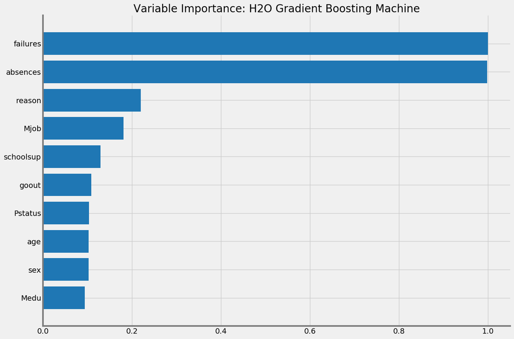

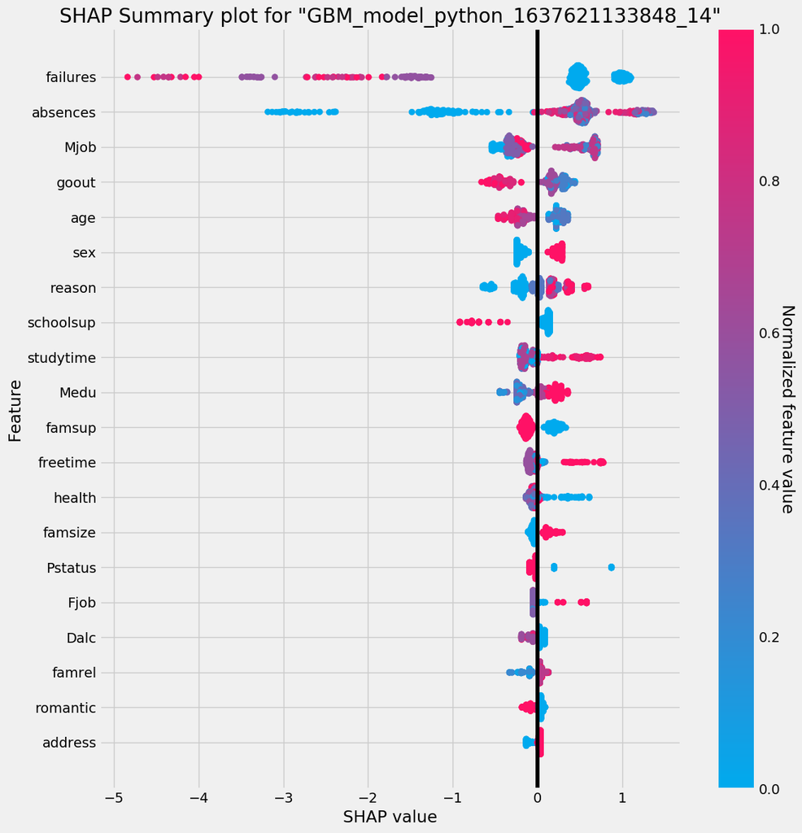

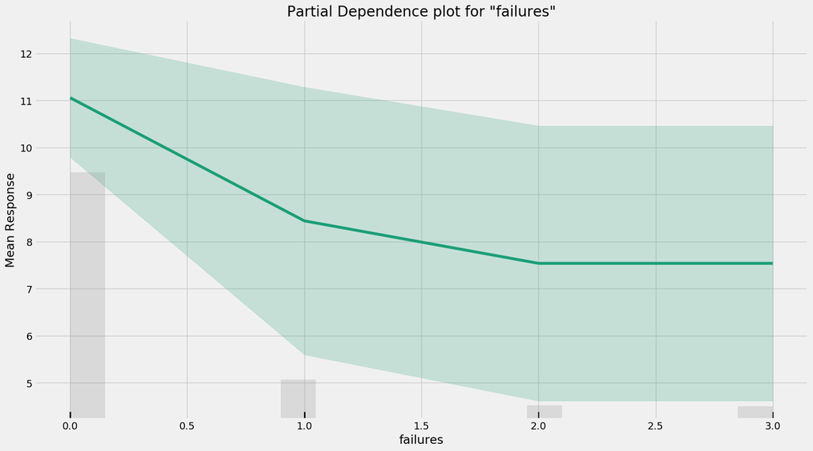

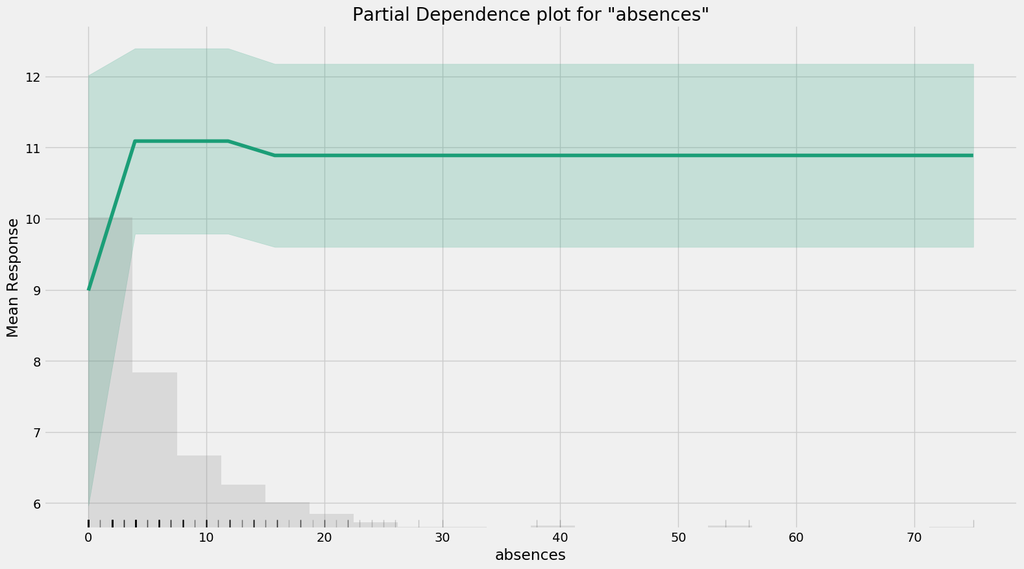

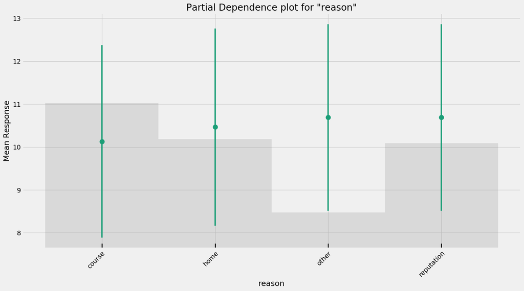